# BA Analytics report

###### 3.2.2. Logistic regression model

```r
##########
# Logistic regrssion
##########

sf.lr = sf %>%
  mutate(satisfaction_v2 = ifelse(satisfaction_v2 == 'satisfied', 1, 0))

trainset.lr = sf.lr[index==1,]
testset.lr = sf.lr[index==2,]

fit = glm(satisfaction_v2 ~ ., data=trainset.lr, family=binomial)
summary(fit)
```

```
##
## Call:
## glm(formula = satisfaction_v2 ~ ., family = binomial, data = trainset.lr)
##
## Deviance Residuals:
##     Min       1Q   Median       3Q      Max
## -3.0167  -0.5796   0.1980   0.5245   3.6593
##
## Coefficients:
##                                       Estimate Std. Error z value Pr(>|z|)
## (Intercept)                         -6.772e+00  7.780e-02 -87.040  < 2e-16 ***
## GenderMale                          -9.555e-01  1.955e-02 -48.876  < 2e-16 ***
## `Customer Type`Loyal Customer        1.979e+00  2.977e-02  66.470  < 2e-16 ***
## Age                                 -7.613e-03  6.791e-04 -11.210  < 2e-16 ***
## `Type of Travel`Personal Travel     -7.821e-01  2.787e-02 -28.060  < 2e-16 ***
## ClassEco                            -7.290e-01  2.529e-02 -28.829  < 2e-16 ***
## ClassEco Plus                       -8.156e-01  3.894e-02 -20.946  < 2e-16 ***
## `Flight Distance`                   -1.365e-04  1.017e-05 -13.426  < 2e-16 ***
## `Seat comfort`                       2.960e-01  1.097e-02  26.969  < 2e-16 ***
## `Departure/Arrival time convenient` -2.045e-01  8.084e-03 -25.303  < 2e-16 ***
## `Food and drink`                    -2.157e-01  1.111e-02 -19.416  < 2e-16 ***
## `Gate location`                      1.099e-01  9.097e-03  12.084  < 2e-16 ***
## `Inflight wifi service`             -7.535e-02  1.053e-02  -7.157 8.26e-13 ***
## `Inflight entertainment`             6.836e-01  9.856e-03  69.354  < 2e-16 ***
## `Online support`                     8.657e-02  1.072e-02   8.078 6.58e-16 ***
## `Ease of Online booking`             2.244e-01  1.381e-02  16.250  < 2e-16 ***
## `On-board service`                   3.031e-01  9.840e-03  30.808  < 2e-16 ***
## `Leg room service`                   2.167e-01  8.344e-03  25.970  < 2e-16 ***
## `Baggage handling`                   9.123e-02  1.108e-02   8.234  < 2e-16 ***
## `Checkin service`                    2.955e-01  8.245e-03  35.843  < 2e-16 ***
## Cleanliness                          1.045e-01  1.147e-02   9.118  < 2e-16 ***
## `Online boarding`                    1.691e-01  1.177e-02  14.368  < 2e-16 ***
## ---
## Signif. codes:  0 '***' 0.001 '**' 0.01 '*' 0.05 '.' 0.1 ' ' 1
##
## (Dispersion parameter for binomial family taken to be 1)
##
##     Null deviance: 125292  on 90993  degrees of freedom
## Residual deviance:  70489  on 90972  degrees of freedom
## AIC: 70533
##
## Number of Fisher Scoring iterations: 5
```

```r
pred = predict(fit, testset, type="response")
predictions = (pred <.5)

table(predictions, testset.lr$satisfaction_v2)
```

```
##
## predictions     0     1
##       FALSE  3272 18002
##       TRUE  14424  3188
```

```r
testset.lr$manual_l=ifelse(testset.lr$satisfaction_v2==1, FALSE, TRUE)
table(predictions, testset.lr$manual_l)
```

```
##
## predictions FALSE  TRUE
##       FALSE 18002  3272
##       TRUE   3188 14424
```

```r
confusionMatrix(table(predictions, testset.lr$manual_l))
```

```
## Confusion Matrix and Statistics
##
##
## predictions FALSE  TRUE
##       FALSE 18002  3272
##       TRUE   3188 14424
##
##                Accuracy : 0.8339
##                  95% CI : (0.8301, 0.8376)
##     No Information Rate : 0.5449
##     P-Value [Acc > NIR] : <2e-16
##
##                   Kappa : 0.6649
##
##  Mcnemar's Test P-Value : 0.3018
##
##             Sensitivity : 0.8496
##             Specificity : 0.8151
##          Pos Pred Value : 0.8462
##          Neg Pred Value : 0.8190
##              Prevalence : 0.5449
##          Detection Rate : 0.4629
##    Detection Prevalence : 0.5471
##       Balanced Accuracy : 0.8323
##
##        'Positive' Class : FALSE
##
```

```r
# find the best cut-off
sf.roc=roc(testset.lr$manual_l, pred)
```

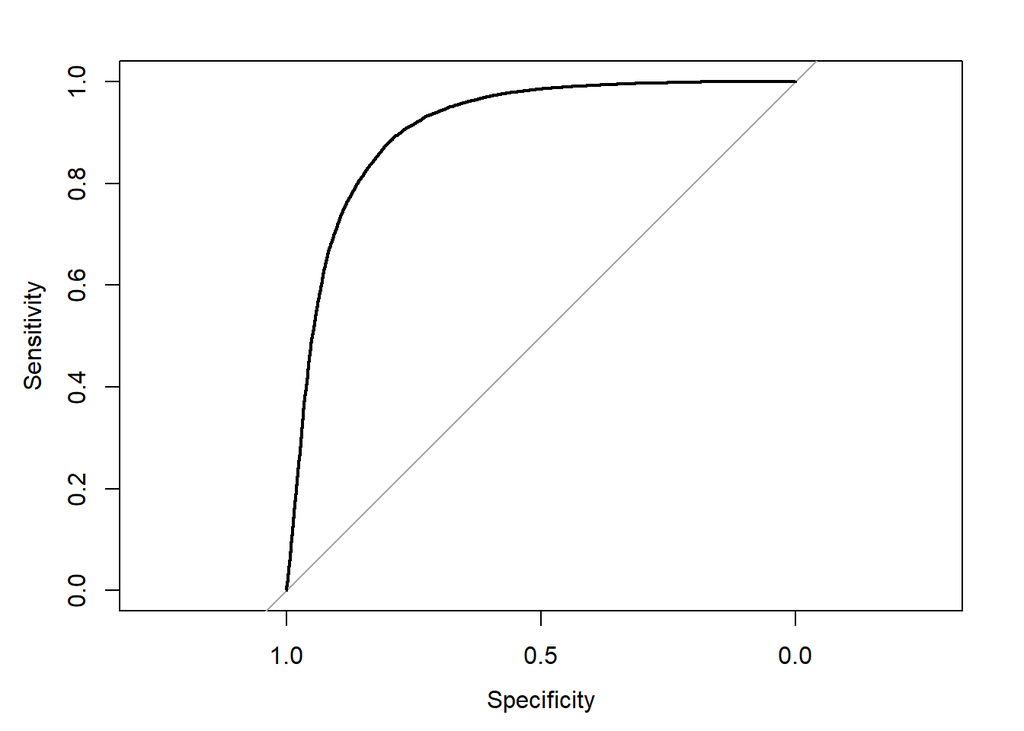

```r
plot(sf.roc)
```

```r
coords(sf.roc, "best")
```

```
##   threshold specificity sensitivity
## 1 0.6104963    0.800991   0.8798599
```

And, here is the threshold graph for the best cut-off in logistic regression model. We also ran for logistic regression model, which is good to set the best cut-off for sensitivity/specificity. For running, we should pre-process the ‘satisfaction_v2’ with making it as a numeric variable, because this model assumes a binomial family in Y value. The best cut-off in both sensitivity and specificity is 0.610, and the best result is 0.8/0.88 for each. Plus, with that, we should notice these are in fact reversed estimates, because we should assume that the actual positive value is ‘neutral/dissatisfied’, which should be more accurately predicted to improve customer services of US airlines.

###### *References

[Consumer satisfaction in the skies soars to record high in annual airline travel survey (2019.05.29)](https://www.cnbc.com/2019/05/28/consumer-satisfaction-soars-to-record-high-in-airline-travel-survey.html) [US airline stocks tumble after Buffett sells stakes (2020.05.04)](https://www.cnbc.com/2020/05/04/us-airline-stocks-tumble-after-buffett-sells-whole-stakes.html)